# Warsztaty eRka & Software Carpentry - część z R

### Słowo wstępu

Jako wprowadzenie do R zachęcam do zapoznania się z ogólnodostępnym fragmentem książki Przemysława Biecka “Przewodnik po pakiecie R. Wydanie III”. Wyczerpuje to temat wprowadzenia do R. Fragment w postaci pliku pod dostępny jest pod [tym adresem](http://biecek.pl/R/PrzewodnikPoPakiecieRWydanieIIIinternet.pdf).

Dostępny fragment obejmuje m.in.:

- Łagodne wprowadzenie do R
- Typy zmiennych i operacje na nich
- Przetwarzanie potokowe
- Wybrane funkcje matematyczne
- Zapisywanie i odczytywanie danych
- Powtarzalne badania
- Budowanie własnych pakietów

Informacje dotyczące instalacji R oraz RStudio znajdują się tymczasowo pod [tym adresem](http://www.erkakrakow.pl/R/warsztaty/pk/instalacja-i-konfiguracja.html). **RStudio nie jest samodzielnym programem. Jest to bardzo funkcjonalna nakładka na R, która pozwala w łatwy i przyjemny sposób wykorzystywać możliwości R. Oznacza to, że poza instalacją RStudio, wymagana jest także instalacja R.**

**Dlaczego warto używać RStudio?**

- zarządzanie wieloma plikami/projektami,
- możliwość automatycznego wysyłania całego skryptu lub fragmentu kodu do konsoli R. Po zaznaczeniu określonego fragmentu kodu po naciśnięciu Ctrl-Enter zadany fragment będzie wykonany w konsoli R,
- wyświetlanie obiektów (nazwa, klasa, wymiary) obecnych w przestrzeni nazw, edytor danych, funkcji i innych obiektów R, po kliknięciu na nazwę zbioru danych obecnego w przestrzeni nazw mamy możliwość edycji tego obiektu,
- uproszczony sposób wczytywania danych z plików poprzez menu,
- podświetlanie słów kluczowych i funkcji,
- kontekstowe uzupełnianie nazw funkcji, zmiennych, właściwości, argumentów funkcji (gdy rozpoczynamy pisanie nazwy funkcji, zmiennej lub argumenty pojawia się lista wszystkich słów, które pasują w danym kontekście),
- zwijanie/rozwijanie kodu funkcji i pętli,
- wsparcie dla pakietów knitra, Sweave i Shiny, łatwa nawigacja po wstawkach kodu,
- domykanie otwartych nawiasów, cudzysłówów, wraz z inteligentnym zaznaczaniem zawartości (dwukrotne kliknięcie we wnętrze nawiasu, zaznacza całą zawartość nawiasu),
- inteligentne wstawianie wcięć połączone z rozpoznawaniem składni (czyli nowe wcięcie dodawane jest w pętlach, funkcjach itp),
- interaktywny debugger.

**[Ściągawka dla RStudio](http://www.rstudio.com/wp-content/uploads/2016/01/rstudio-IDE-cheatsheet.pdf)**

**Pakiety instalujemy za pomocą funkcji install.packages(‘nazwa_pakietu’). Na dobry początek warto zainstalować pakiet [pacman](https://cran.r-project.org/web/packages/pacman/pacman.pdf).**

Pod [tym adresem](https://cran.r-project.org/web/views/) można znaleźć listę dostępnych pakietów na głównym repozytorium CRAN.

### Wprowadzenie - kod z warsztatów

**Korzystanie z pomocy**

- ?nazwaFunkcji
- help(nazwaFunkcji
- args(nazwaFunkcji)
- find(fragmentNazwyFunkcji)
- help.search(“poszukiwane_slowo”)
- www.google.pl
- www.stackoverflow.com
- TABulator

```r
# Komentarz
1 + 1 # Komentarz
```

```r
# Dzialania arytmetyczne
2 + 2 - 1       # dodawanie i odejmowanie
2^10            # potegowanie
(23-1)*(23+1)   # mnozenie
10/3.3          # dzielenie
1/0             # liczby specjalne (nieskonczonosc)
log(10)         # logarytmy
log(-1)         # liczby specjalne (NaN jako wartość nieznana)
5 %%  3         # reszta z dzielenia (5 przez 3)
5 %/% 3         # część całkowita z dzielenia (5 przez 3)

# i wiele, wiele innych...

# Challange A: co zwróci wyrażenie 'class(1/0)' ?
# Challange B: co zwróci wyrażenie 'class(log(-1))' ?
```

```r
# Napisy

"Ala"                       # w cudzysłowie
'Ala'                       # w apostrofie
paste("Ala", "ma", "kota")  # łączenie napisów za pomocą paste. Znaki typu + oraz & nie działają
nchar("Hello")              # liczba znaków
tolower("Hello")            # konwersja do malych liter
substr("Hello", 2, 3)       # wycinanie fragmentu napisu

# i wiele, wiele innych...

# Challange C: co zwróci wyrażenie 'class("Ala")' ?
# Challange D: czym się różni paste od paste0 ?
# Czy zamiast paste można stosować zamiennik typu "Ala" + "ma" + "kota", lub "Ala" & "ma" & "kota" ?
# Jakaś alternatywa do paste?
```

```r
# Zmienne

licznik    <- 1
mianownik  <- 10

ulamek     <- licznik / mianownik
ulamek

(ulamek    <- licznik / mianownik) # nawias pozwala na wykonanie dwóch powyższych linijek jednocześnie

# Challange E: Co zwróci zmienna 'ulamek', gdy wykonamy następujące przypisanie
mianownik <- 2
# ?
ulamek
# Dlaczego tak się stało?
```

```r
# Wielkość liter ma znaczenie!

a <- 1
A <- 2
a == A
```

### Odpowiedzi

**Challange A**

```r
class(1/0)          # Inf jest liczbą
```

```
## [1] "numeric"
```

```r
Inf > 10^10^10      # trzeba być czujnym
```

```
## [1] FALSE
```

```r
Inf == 10^10^10     # trzeba być czujnym
```

```
## [1] TRUE
```

**Challange B**

```r
class(log(-1))      # NaN jest liczbą
```

```
## [1] "numeric"
```

```r
NaN > 0             # NA jest wartością logiczną określającą brak możliwości jednoznacznego przypisania TRUE lub FALSE
```

```
## [1] NA
```

**Challange C**

```r
class("Ala")
```

```
## [1] "character"
```

**Challange D**

```r
paste("Ala", "ma", "kota")
```

```
## [1] "Ala ma kota"
```

```r
paste0("Ala", "ma", "kota")
```

```
## [1] "Alamakota"
```

```r
# "Ala" + "ma" + "kota" nie zadziała
# "Ala" & "ma" & "kota" nie zadziała
cat("Ala", "ma", "kota")
```

```
## Ala ma kota
```

```r
licznik    <- 1
mianownik  <- 10
(ulamek <- licznik/mianownik)
```

```
## [1] 0.1
```

**Challange E**

```r
mianownik <- 2
ulamek              # przypisanie do zmiennej to przypisanie pewnej etykiety do wyniku działania wyrażenia, tzn. że zmienna nie pamięta jakie kroki pośrednie były wykonywane, a jedynie pamięta wynik. W momencie zmiany wartości zmiennej 'mianownik', zmienna 'ulamek' nie ulega aktualizacji.
```

```
## [1] 0.1
```

### Analiza danych z krokomierza

W pliku krokomierz.csv znajdują się tabelka 52 wiersze na 7 kolumn, gdzie wiersze odpowiadają kolejnym tygodniom 2015 roku, natomiast kolumny odpowiadają poszczególnym dniom tygodnia. Tabela zawiera informacje o liczbie kroków wykonanych każdego dnia 2015 roku.

**Wczytywanie danych z pliku csv**

```r
dane <- read.csv("dane/krokomierz.csv") # tutaj należy podać ścieżkę do pliku
# ?read.csv dla plików csv z kolumnami rozdzielanymi przecinkami (domyślnie)
# ?read.csv dla plików csv z kolumnami rozdzielanymi średnikami (domyślnie)

# LifeHack, funkcja url() pozwala na zaciąganie danych bezpośrednio z internetu
```

**Szybki wgląd w dane**

```r
colnames(dane)  # wektor nazw kolumn
```

```
## [1] "Cz"  "Pt"  "Sb"  "Nd"  "Pon" "Wt"  "Sr"
```

```r
rownames(dane)  # wektor nazw wierszy
```

```
##  [1] "1"  "2"  "3"  "4"  "5"  "6"  "7"  "8"  "9"  "10" "11" "12" "13" "14"
## [15] "15" "16" "17" "18" "19" "20" "21" "22" "23" "24" "25" "26" "27" "28"
## [29] "29" "30" "31" "32" "33" "34" "35" "36" "37" "38" "39" "40" "41" "42"
## [43] "43" "44" "45" "46" "47" "48" "49" "50" "51" "52"
```

```r
nrow(dane)      # liczba wierszy
```

```
## [1] 52
```

```r
ncol(dane)      # liczba kolumn
```

```
## [1] 7
```

```r
head(dane)      # wyświetla 6 pierwszych wierszy tabeli (domyślnie)
```

```
##      Cz   Pt   Sb Nd Pon Wt   Sr
## 1    NA   NA   NA NA  NA NA   NA
## 2    NA   NA   NA NA  NA NA   NA
## 3    NA   NA   NA NA  NA NA   NA
## 4    NA   NA   NA NA  NA NA   NA
## 5    NA   NA   NA NA  NA NA   NA
## 6 10357 5743 4169  0   0 33 4276
```

```r
tail(dane)      # wyświetla 6 ostatnich wierszy tabeli (domyślnie)
```

```
##      Cz    Pt   Sb   Nd  Pon   Wt   Sr
## 47 5785  6174 2142 1114 7562 2572 6053
## 48 2707 13217 4523 1836 1017 3569 1634
## 49 3035  4826 1819 2802 9836 7678 5148
## 50 4696  5201  664 1243 5171 5404 5198
## 51 5587  6017 9641 3669 5222   NA   NA
## 52   NA    NA   NA   NA   NA    0 1869
```

```r
summary(dane)   # szybkie statystyki, osobno dla każdej kolumny
```

```
##        Cz              Pt              Sb              Nd
##  Min.   :  220   Min.   :    0   Min.   :    0   Min.   :    0
##  1st Qu.: 4289   1st Qu.: 3521   1st Qu.: 1052   1st Qu.: 1146
##  Median : 5518   Median : 5590   Median : 2845   Median : 2532
##  Mean   : 5518   Mean   : 6027   Mean   : 3904   Mean   : 3468
##  3rd Qu.: 6278   3rd Qu.: 6235   3rd Qu.: 5788   3rd Qu.: 5504
##  Max.   :12952   Max.   :17826   Max.   :13771   Max.   :11497
##  NA's   :7       NA's   :7       NA's   :7       NA's   :6
##       Pon              Wt              Sr
##  Min.   :    0   Min.   :    0   Min.   :    0
##  1st Qu.: 2645   1st Qu.: 3129   1st Qu.: 3487
##  Median : 5222   Median : 5404   Median : 5614
##  Mean   : 5008   Mean   : 5077   Mean   : 5390
##  3rd Qu.: 7281   3rd Qu.: 6980   3rd Qu.: 7169
##  Max.   :13067   Max.   :11929   Max.   :12711
##  NA's   :7       NA's   :7       NA's   :7
```

```r
class(dane)     # zmienna dane jest ramką danych, czyli tablicą, której różne kolumny mogą mieć różne typy danych
```

```
## [1] "data.frame"
```

```r
# LifeHack, gdy nie używamy RStudio, dane możemy przeglądać za pomocą funkcji edit(dane), natomiast wpisując fix(dane) będziemy mogli także zmieniać wartości tabeli
```

**Wyciąganie danych**

```r
dane[10, 1]         # bezpośrednio przez podanie współrzędnych
```

```
## [1] 5720
```

```r
dane[10,]           # cały wiersz
```

```
##      Cz   Pt Sb   Nd  Pon   Wt   Sr
## 10 5720 1126  0 6514 1354 3155 6753
```

```r
dane[,1]            # cała kolumna
```

```
##  [1]    NA    NA    NA    NA    NA 10357 11202  9636  5518  5720  2073
## [12]  1172  1135  1150  3630 12569  4473  3811  5396  4455  3357  9783
## [23]   220  6522 12952  6278  5872  5094 10122    NA  6371  6914  7235
## [34]  4317  6205  5978  4635  6126  5532   487  4538  5424  5520  4289
## [45]  4605  5806  5785  2707  3035  4696  5587    NA
```

```r
dane[10, 'Cz']      # do kolumny możemy odwoływać się także poprzez jej nazwę
```

```
## [1] 5720
```

```r
dane$Cz[10]         # za pomocą $ przechodzimy do kolumny (wtedy dane$Cz traktowane jest jako wektor) i wybieramy wartość z 10 pozycji wektora (czyli 10 wiersza)
```

```
## [1] 5720
```

```r
# Można wybierać jednocześnie całe podzbiory, poprzez użycie wektorów
# 1:10 to to samo co c(1,2,3,4,5,6,7,8,9,10) i to samo seq(1,10,1)
# Sprawdź ?c oraz ?seq
dane[1:10, 1:2]
```

```
##       Cz    Pt
## 1     NA    NA
## 2     NA    NA
## 3     NA    NA
## 4     NA    NA
## 5     NA    NA
## 6  10357  5743
## 7  11202  5670
## 8   9636 17826
## 9   5518  5338
## 10  5720  1126
```

```r
dane[1:10, c("Sb", "Nd")] # wektory mogą także zawierać nazwy kolumn
```

```
##      Sb    Nd
## 1    NA    NA
## 2    NA    NA
## 3    NA    NA
## 4    NA    NA
## 5    NA    NA
## 6  4169     0
## 7  1818   135
## 8  9180 11497
## 9  8776  4323
## 10    0  6514
```

```r
seq_along(colnames(dane)) # ?seq_along
```

```
## [1] 1 2 3 4 5 6 7
```

```r
dane_tygodnie_parzyste <- dane[seq(2,52,2), ] # wybranie danych z parzystych tygodni
rownames(dane_tygodnie_parzyste)
```

```
##  [1] "2"  "4"  "6"  "8"  "10" "12" "14" "16" "18" "20" "22" "24" "26" "28"
## [15] "30" "32" "34" "36" "38" "40" "42" "44" "46" "48" "50" "52"
```

```r
dane_tydz10 <- dane[10,]    # wybranie danych dla 10 tygodnia
dane_tydz10[-1]             # dzięki znakowi - można wyrzucać współrzędne (w tym przypadku wyświetlą się dane dla całego tygodnia poza czwartkiem)
```

```
##      Pt Sb   Nd  Pon   Wt   Sr
## 10 1126  0 6514 1354 3155 6753
```

```r
dane_tydz10[-1:-7]          # tutaj wyświetli się pusta ramka, ponieważ usuwamy wszystkie dni
```

```
## ramka danych z zerową liczbą kolumn oraz 1 wierszem
```

```r
dane_tydz10[FALSE]          # co się stanie jak zamiast indeksów umieścimy wartości logiczne?
```

```
## ramka danych z zerową liczbą kolumn oraz 1 wierszem
```

```r
dane_tydz10[c(FALSE,TRUE)]  # dane_tydz10 to wektor siedmioelementowy, R automatycznie dopasowuje wektor dwuelementowy na potrzeby wybrania odpowiednich wartości, robi to poprzez replikację wektora krótszego, aż do momentu uzyskania pożądanego wyniku
```

```
##      Pt   Nd   Wt
## 10 1126 6514 3155
```

```r
dane_tydz10[c(FALSE,TRUE,FALSE,TRUE,FALSE,TRUE,FALSE)] # to jest równoważne z powyższym, przy czym tutaj nie jest już potrzebna replikacja
```

```
##      Pt   Nd   Wt
## 10 1126 6514 3155
```

```r
dane_tydz10 < 1000          # w ten sposób otrzymamy wektor z wartościami logicznymi, gdzie TRUE oznacza, że wartość na danej współrzędnej spełnia warunek, natomiast FALSE oznacza, że warunek nie jest spełniony
```

```
##       Cz    Pt   Sb    Nd   Pon    Wt    Sr
## 10 FALSE FALSE TRUE FALSE FALSE FALSE FALSE
```

```r
dane_tydz10[dane_tydz10 < 1000] # mix powyższych pozwala nam na wyświetlanie wartości spełniających nasz warunek
```

```
## [1] 0
```

```r
dane_tydz10[dane_tydz10 < 1000] <- NA # dzięki temu możemy te dane podmienić wg naszych potrzeb
dane_tydz10
```

```
##      Cz   Pt Sb   Nd  Pon   Wt   Sr
## 10 5720 1126 NA 6514 1354 3155 6753
```

**Proste obliczenia** Jest sporo pakietów, które pozwalają na niezłą zabawę z danymi bez tworzenia wielu linijek kodu. Sama biblioteka bazowa daje duże możliwości.

```r
rowSums(dane, na.rm = TRUE)  # sumy po wierszach
```

```
##  [1]     0     0     0     0     0 24578 28064 62163 27357 24622 25608
## [12] 10023  5108 14224 47268 30861 36736 31540 63032 45161 30076 42365
## [23] 32560 52267 52892 41238 60011 48626 39891 17254 39545 43101 33668
## [34] 33110 37270 29067 30515 23893 18257 31417 38351 31082 29239 38462
## [45] 14616 31363 31402 28503 35144 27577 30136  1869
```

```r
colSums(dane, na.rm = TRUE)  # sumy po kolumnach
```

```
##     Cz     Pt     Sb     Nd    Pon     Wt     Sr
## 248289 271222 175695 159520 225357 228468 242561
```

```r
rowMeans(dane, na.rm = TRUE) # średnie po wierszach
```

```
##  [1]       NaN       NaN       NaN       NaN       NaN 3511.1429 4009.1429
##  [8] 8880.4286 3908.1429 3517.4286 3658.2857 1431.8571  729.7143 2032.0000
## [15] 6752.5714 4408.7143 5248.0000 4505.7143 9004.5714 6451.5714 4296.5714
## [22] 6052.1429 4651.4286 7466.7143 7556.0000 5891.1429 8573.0000 6946.5714
## [29] 9972.7500 4313.5000 5649.2857 6157.2857 4809.7143 4730.0000 5324.2857
## [36] 4152.4286 4359.2857 3413.2857 2608.1429 4488.1429 5478.7143 4440.2857
## [43] 4177.0000 5494.5714 2088.0000 4480.4286 4486.0000 4071.8571 5020.5714
## [50] 3939.5714 6027.2000  934.5000
```

```r
colMeans(dane, na.rm = TRUE) # średnie po kolumnach
```

```
##       Cz       Pt       Sb       Nd      Pon       Wt       Sr
## 5517.533 6027.156 3904.333 3467.826 5007.933 5077.067 5390.244
```

```r
# dla mediany nie ma, ale to można szybko naprawić - nawet bez stosowania for
# Sprwadź ?apply
(rowMedians <- apply(dane,1,median, na.rm = TRUE))
```

```
##  [1]     NA     NA     NA     NA     NA 4169.0 2983.0 9180.0 4323.0 3155.0
## [11] 4436.0 1172.0  729.0  930.0 4514.0 2419.0 5746.0 4819.0 8431.0 5877.0
## [21] 3357.0 6061.0 5943.0 7141.0 7524.0 6278.0 8605.0 5725.0 9971.0 4912.0
## [31] 5226.0 6763.0 4519.0 4317.0 5986.0 5337.0 4626.0 3199.0 3449.0 4025.0
## [41] 5590.0 4858.0 4397.0 5129.0 1489.0 4797.0 5785.0 2707.0 4826.0 5171.0
## [51] 5587.0  934.5
```

```r
(colMedians <- apply(dane,2,median, na.rm = TRUE))
```

```
##     Cz     Pt     Sb     Nd    Pon     Wt     Sr
## 5518.0 5590.0 2845.0 2532.5 5222.0 5404.0 5614.0
```

**Bardzo proste wykresy**

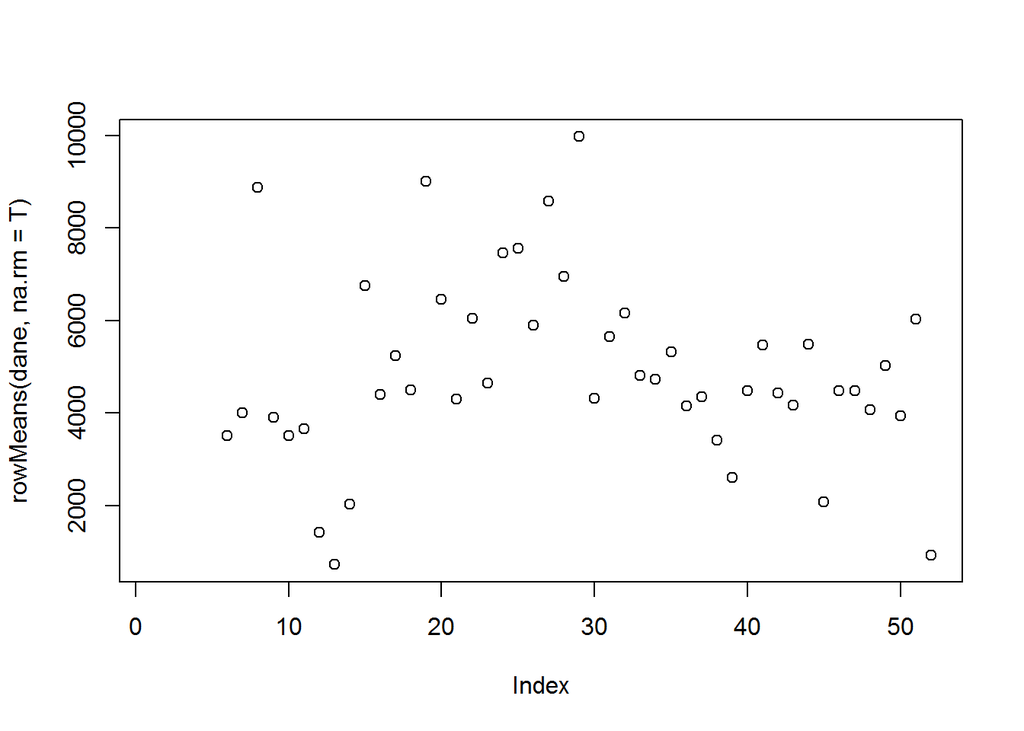

```r
# ?plot
plot(rowMeans(dane, na.rm=T)) # numer tygodnia ~ średnia liczba kroków
```

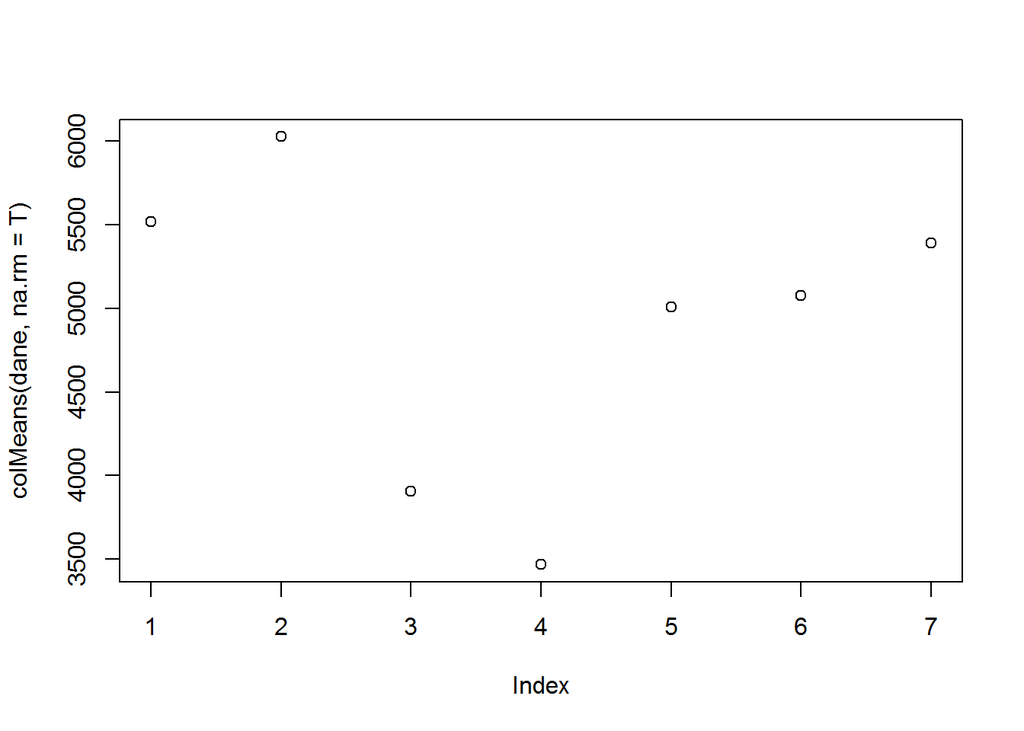

```r
plot(colMeans(dane, na.rm=T)) # dzień tygodnia ~ średnia liczba kroków
```

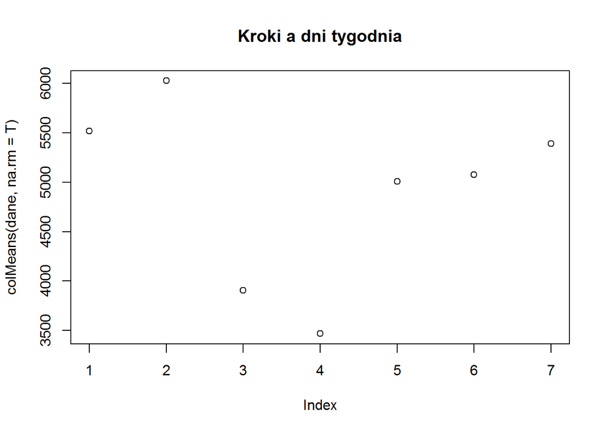

```r
plot(colMeans(dane, na.rm=T), main="Kroki a dni tygodnia") # dodawanie tytułu
```

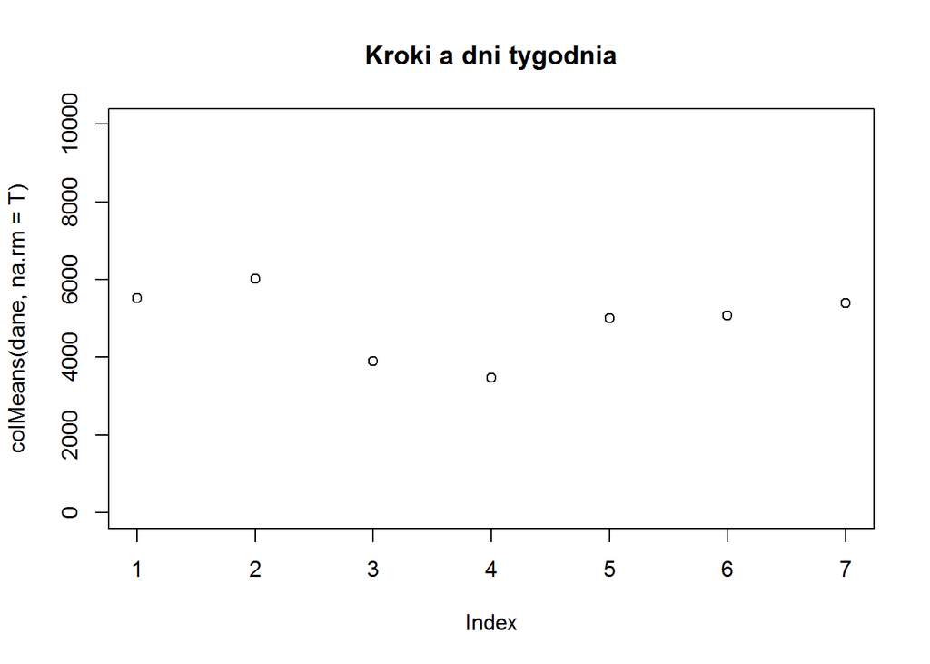

```r
plot(colMeans(dane, na.rm=T), main="Kroki a dni tygodnia", ylim=c(0,10000)) # poprawa zakresu na osi 0Y
```

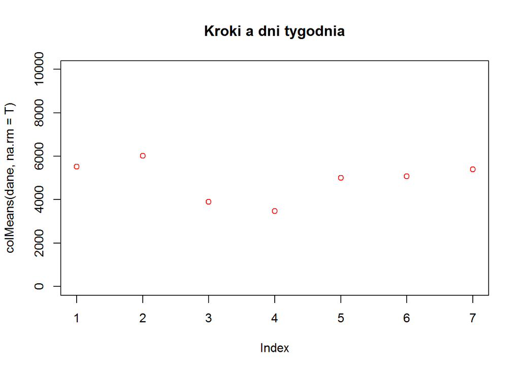

```r
plot(colMeans(dane, na.rm=T), main="Kroki a dni tygodnia", ylim=c(0,10000), col="red") # kolor punktów
```

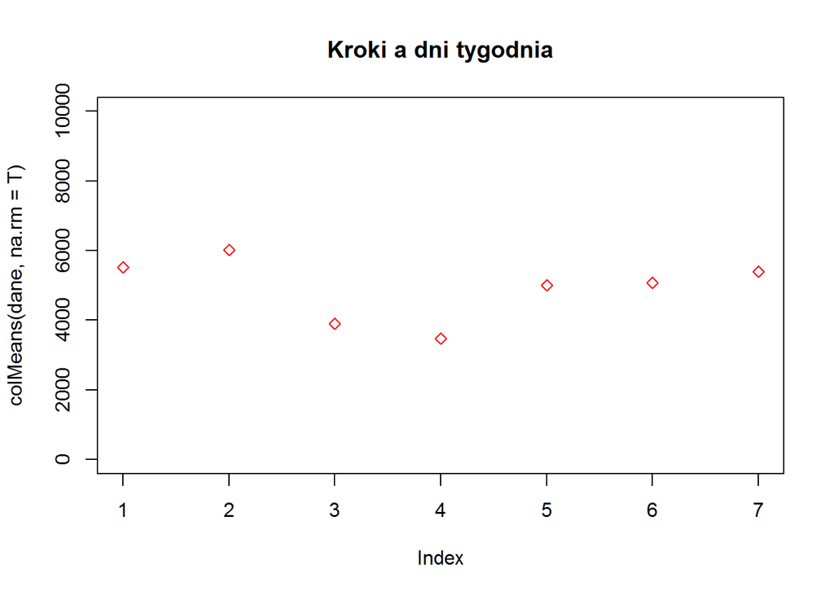

```r
plot(colMeans(dane, na.rm=T), main="Kroki a dni tygodnia", ylim=c(0,10000), col="red", pch=23) # kształt punktów
```

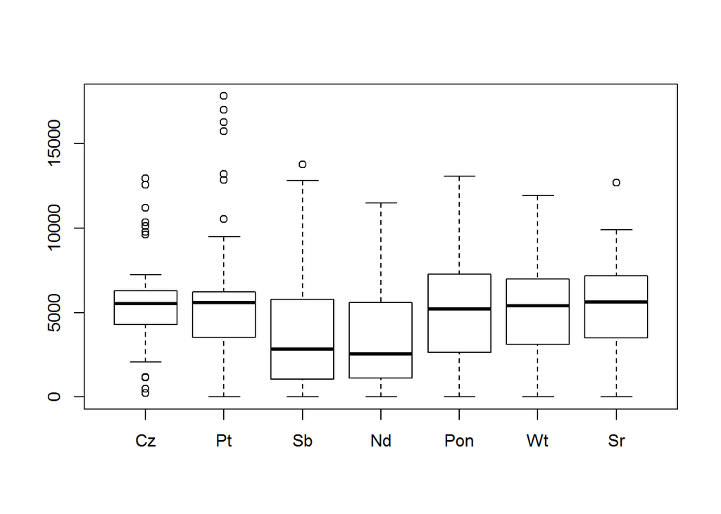

```r
# ?boxplot
boxplot(dane) # wykres pudełkowy
```